# Setup

```python
# Python ≥3.5 is required
import sys
assert sys.version_info >= (3, 5)

# Scikit-Learn ≥0.20 is required
import sklearn
assert sklearn.__version__ >= "0.20"

# Common imports
import numpy as np
import os

# to make this notebook's output stable across runs
np.random.seed(42)

# To plot pretty figures
%matplotlib inline
import matplotlib as mpl
import matplotlib.pyplot as plt
mpl.rc('axes', labelsize=14)
mpl.rc('xtick', labelsize=12)
mpl.rc('ytick', labelsize=12)

# Where to save the figures
PROJECT_ROOT_DIR = "."
CHAPTER_ID = "training_linear_models"
IMAGES_PATH = os.path.join(PROJECT_ROOT_DIR, "images", CHAPTER_ID)
os.makedirs(IMAGES_PATH, exist_ok=True)

def save_fig(fig_id, tight_layout=True, fig_extension="png", resolution=300):
    path = os.path.join(IMAGES_PATH, fig_id + "." + fig_extension)
    print("Saving figure", fig_id)
    if tight_layout:
        plt.tight_layout()
    plt.savefig(path, format=fig_extension, dpi=resolution)
```

"In this chapter, we will start by looking at the Linear Regression model, one of the  
simplest models there is. We will discuss two very different ways to train it:

- Using a direct “closed-form” equation that directly computes the model parameters  
  that best fit the model to the training set (i.e., the model parameters that  
  minimize the cost function over the training set).
- Using an iterative optimization approach, called Gradient Descent (GD), that  
  gradually tweaks the model parameters to minimize the cost function over the  
  training set, eventually converging to the same set of parameters as the first  
  method. We will look at a few variants of Gradient Descent that we will use again  
  and again when we study neural networks in Part II: Batch GD, Mini-batch GD,  
  and Stochastic GD."

"Next we will look at Polynomial Regression, a more complex model that can fit nonlinear  
datasets. Since this model has more parameters than Linear Regression, it is  
more prone to overfitting the training data, so we will look at how to detect whether  
or not this is the case, using learning curves, and then we will look at several regularization  
techniques that can reduce the risk of overfitting the training set."

"Finally, we will look at two more models that are commonly used for classification  
tasks: Logistic Regression and Softmax Regression."

# Linear Regression Using the Normal Equation

[figure not shown]

"In Chapter 2 we saw that the most common performance measure  
of a regression model is the Root Mean Square Error (RMSE) (Equation 2-1). Therefore,  
to train a Linear Regression model, you need to find the value of θ that minimizes  
the RMSE. In practice, it is simpler to minimize the Mean Square Error (MSE)  
than the RMSE, and it leads to the same result (because the value that minimizes a  
function also minimizes its square root)."

[figure not shown]

# # Linear Regression Using the Normal Equation

[figure not shown]

Generating some random data

```python
import numpy as np

X = 2 * np.random.rand(100, 1)
y = 4 + 3 * X + np.random.randn(100, 1)
```

```
Saving figure generated_data_plot
```

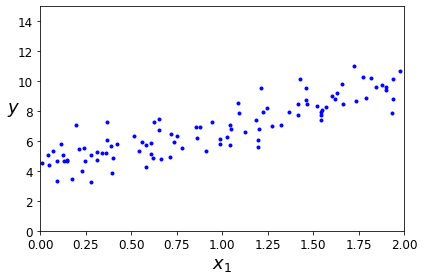

```python
plt.plot(X, y, "b.")
plt.xlabel("$x_1$", fontsize=18)
plt.ylabel("$y$", rotation=0, fontsize=18)
plt.axis([0, 2, 0, 15])
save_fig("generated_data_plot")
plt.show()
```

```python
# add x0 = 1 to each instance
X_b = np.c_[np.ones((100, 1)), X]
# Equation above!
theta_best = np.linalg.inv(X_b.T.dot(X_b)).dot(X_b.T).dot(y)
```

"The actual function that we used to generate the data is y = 4 + 3x0 + Gaussian noise.  
Let’s see what the equation found:"

```python
theta_best
```

```
array([[4.21509616],
       [2.77011339]])
```

"We would have hoped for θ0 = 4 and θ1 = 3 instead of θ0 = 4.215 and θ1 = 2.770. Close  
enough, but the noise made it impossible to recover the exact parameters of the original  
function"

"Now you can make predictions using θ:"

```python
X_new = np.array([[0], [2]])
# add x0 = 1 to each instance
X_new_b = np.c_[np.ones((2, 1)), X_new]
y_predict = X_new_b.dot(theta_best)
y_predict
```

```
array([[4.21509616],
       [9.75532293]])
```

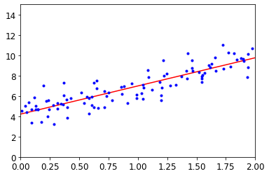

```python
plt.plot(X_new, y_predict, "r-")
plt.plot(X, y, "b.")
plt.axis([0, 2, 0, 15])
plt.show()
```

```python
from sklearn.linear_model import LinearRegression

lin_reg = LinearRegression()
lin_reg.fit(X, y)
lin_reg.intercept_, lin_reg.coef_
```

```
(array([4.21509616]), array([[2.77011339]]))
```

```python
lin_reg.predict(X_new)
```

```
array([[4.21509616],
       [9.75532293]])
```

"The LinearRegression class is based on the scipy.linalg.lstsq() function (the name stands for "least squares"), which you could call directly:"

```python
theta_best_svd, residuals, rank, s = np.linalg.lstsq(X_b, y, rcond=1e-6)
theta_best_svd
```

```
array([[4.21509616],
       [2.77011339]])
```

"This function computes $\mathbf{X}^+\mathbf{y}$, where $\mathbf{X}^{+}$ is the pseudoinverse of $\mathbf{X}$ (specifically the Moore-Penrose inverse). You can use np.linalg.pinv() to compute the pseudoinverse directly:"

```python
np.linalg.pinv(X_b).dot(y)
```

```
array([[4.21509616],
       [2.77011339]])
```

## Computational Complexity

"The Normal Equation computes the inverse of XT · X, which is an n × n matrix  
(where n is the number of features). The computational complexity of inverting such a  
matrix is typically about O(n2.4) to O(n3) (depending on the implementation). In  
other words, if you double the number of features, you multiply the computation  
time by roughly 22.4 = 5.3 to 23 = 8."

WARNING: "The Normal Equation gets very slow when the number of features  
grows large (e.g., 100,000)."

"On the positive side, this equation is linear with regards to the number of instances in  
the training set (it is O(m)), so it handles large training sets efficiently, provided they  
can fit in memory."

"Also, once you have trained your Linear Regression model (using the Normal Equation  
or any other algorithm), predictions are very fast: the computational complexity  
is linear with regards to both the number of instances you want to make predictions  
on and the number of features. In other words, making predictions on twice as many  
instances (or twice as many features) will just take roughly twice as much time."

"Now we will look at very different ways to train a Linear Regression model, better  
suited for cases where there are a large number of features, or too many training  
instances to fit in memory."

# Gradient Descent

"Gradient Descent is a very generic optimization algorithm capable of finding optimal  
solutions to a wide range of problems. The general idea of Gradient Descent is to  
tweak parameters iteratively in order to minimize a cost function."

"Suppose you are lost in the mountains in a dense fog; you can only feel the slope of  
the ground below your feet. A good strategy to get to the bottom of the valley quickly  
is to go downhill in the direction of the steepest slope. This is exactly what Gradient  
Descent does: it measures the local gradient of the error function with regards to the  
parameter vector θ, and it goes in the direction of descending gradient. Once the gradient  
is zero, you have reached a minimum!"

"Concretely, you start by filling θ with random values (this is called random initialization),  
and then you improve it gradually, taking one baby step at a time, each step  
attempting to decrease the cost function (e.g., the MSE), until the algorithm converges  
to a minimum (see Figure 4-3)."

[figure not shown]

"An important parameter in Gradient Descent is the size of the steps, determined by  
the learning rate hyperparameter. If the learning rate is too small, then the algorithm  
will have to go through many iterations to converge, which will take a long time (see  
Figure 4-4)."

[figure not shown]

"On the other hand, if the learning rate is too high, you might jump across the valley  
and end up on the other side, possibly even higher up than you were before. This  
might make the algorithm diverge, with larger and larger values, failing to find a good  
solution (see Figure 4-5)."

[figure not shown]

"Finally, not all cost functions look like nice regular bowls. There may be holes, ridges,  
plateaus, and all sorts of irregular terrains, making convergence to the minimum very  
difficult. Figure 4-6 shows the two main challenges with Gradient Descent: if the random  
initialization starts the algorithm on the left, then it will converge to a local minimum,  
which is not as good as the global minimum. If it starts on the right, then it will  
take a very long time to cross the plateau, and if you stop too early you will never  
reach the global minimum."

[figure not shown]

"Fortunately, the MSE cost function for a Linear Regression model happens to be a  
convex function, which means that if you pick any two points on the curve, the line  
segment joining them never crosses the curve. This implies that there are no local  
minima, just one global minimum. It is also a continuous function with a slope that  
never changes abruptly.4 These two facts have a great consequence: Gradient Descent  
is guaranteed to approach arbitrarily close the global minimum (if you wait long  
enough and if the learning rate is not too high)."

"In fact, the cost function has the shape of a bowl, but it can be an elongated bowl if  
the features have very different scales. Figure 4-7 shows Gradient Descent on a training  
set where features 1 and 2 have the same scale (on the left), and on a training set  
where feature 1 has much smaller values than feature 2 (on the right). Since feature 1 is smaller,  
it takes a larger change in θ1 to affect the cost function, which is why the bowl is elongated along the θ1 axis."

[figure not shown]

"As you can see, on the left the Gradient Descent algorithm goes straight toward the  
minimum, thereby reaching it quickly, whereas on the right it first goes in a direction  
almost orthogonal to the direction of the global minimum, and it ends with a long  
march down an almost flat valley. It will eventually reach the minimum, but it will  
take a long time."

WARNING: "When using Gradient Descent, you should ensure that all features  
have a similar scale (e.g., using Scikit-Learn’s StandardScaler  
class), or else it will take much longer to converge."

## Batch Gradient Descent

"To implement Gradient Descent, you need to compute the gradient of the cost function  
with regards to each model parameter θj. In other words, you need to calculate  
how much the cost function will change if you change θj just a little bit. This is called  
a partial derivative. It is like asking “what is the slope of the mountain under my feet  
if I face east?” and then asking the same question facing north (and so on for all other  
dimensions, if you can imagine a universe with more than three dimensions). Equation  
4-5 computes the partial derivative of the cost function with regards to parameter  
θj"

[figure not shown]

"Instead of computing these gradients individually, you can use Equation 4-6 to compute  
them all in one go. The gradient vector, noted ∇θMSE(θ), contains all the partial  
derivatives of the cost function (one for each model parameter)."

[figure not shown]

"Once you have the gradient vector, which points uphill, just go in the opposite direction  
to go downhill. This means subtracting ∇θMSE(θ) from θ. This is where the  
learning rate η comes into play:6 multiply the gradient vector by η to determine the  
size of the downhill step (Equation 4-7)."

[figure not shown]

WARNING: "Notice that 4.6 involves calculations over the full training  
set X, at each Gradient Descent step! This is why the algorithm is  
called Batch Gradient Descent: it uses the whole batch of training  
data at every step. As a result it is terribly slow on very large training  
sets (but we will see much faster Gradient Descent algorithms  
shortly). However, Gradient Descent scales well with the number of  
features; training a Linear Regression model when there are hundreds  
of thousands of features is much faster using Gradient  
Descent than using the Normal Equation."

```python
theta_path_bgd = []

def plot_gradient_descent(theta, eta, theta_path=None):
    m = len(X_b)
    plt.plot(X, y, "b.")
    n_iterations = 1000
    for iteration in range(n_iterations):
        if iteration < 10:
            y_predict = X_new_b.dot(theta)
            style = "b-" if iteration > 0 else "r--"
            plt.plot(X_new, y_predict, style)
        gradients = 2/m * X_b.T.dot(X_b.dot(theta) - y)
        theta = theta - eta * gradients
        if theta_path is not None:
            theta_path.append(theta)
    plt.xlabel("$x_1$", fontsize=18)
    plt.axis([0, 2, 0, 15])
    plt.title(r"$\eta = {}$".format(eta), fontsize=16)
```

```
Saving figure gradient_descent_plot
```

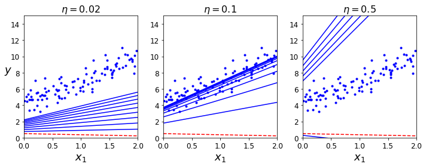

```python
np.random.seed(42)
theta = np.random.randn(2,1)  # random initialization

plt.figure(figsize=(10,4))
plt.subplot(131); plot_gradient_descent(theta, eta=0.02)
plt.ylabel("$y$", rotation=0, fontsize=18)
plt.subplot(132); plot_gradient_descent(theta, eta=0.1, theta_path=theta_path_bgd)
plt.subplot(133); plot_gradient_descent(theta, eta=0.5)

save_fig("gradient_descent_plot")
plt.show()
```

```python
# learning rate
eta = 0.1
n_iterations = 1000
m = 100

# random initialization
theta = np.random.randn(2,1)

for iteration in range(n_iterations):
    gradients = 2/m * X_b.T.dot(X_b.dot(theta) - y)
    theta = theta - eta * gradients
```

```python
theta
```

```
array([[4.21509616],
       [2.77011339]])
```

"Hey, that’s exactly what the Normal Equation found! Gradient Descent worked perfectly.  
But what if you had used a different learning rate eta? Figure 4-8 shows the  
first 10 steps of Gradient Descent using three different learning rates (the dashed line  
represents the starting point)."

[figure not shown]

"On the left, the learning rate is too low: the algorithm will eventually reach the solution,  
but it will take a long time. In the middle, the learning rate looks pretty good: in  
just a few iterations, it has already converged to the solution. On the right, the learning  
rate is too high: the algorithm diverges, jumping all over the place and actually  
getting further and further away from the solution at every step."

TIP: "To find a good learning rate, you can use grid search (see Chapter 2). However, you  
may want to limit the number of iterations so that grid search can eliminate models  
that take too long to converge."

TIP 2: "You may wonder how to set the number of iterations. If it is too low, you will still be  
far away from the optimal solution when the algorithm stops, but if it is too high, you  
will waste time while the model parameters do not change anymore. A simple solution  
is to set a very large number of iterations but to interrupt the algorithm when the  
gradient vector becomes tiny—that is, when its norm becomes smaller than a tiny  
number ϵ (called the tolerance)—because this happens when Gradient Descent has  
(almost) reached the minimum."

## Stochastic Gradient Descent

"The main problem with Batch Gradient Descent is the fact that it uses the whole  
training set to compute the gradients at every step, which makes it very slow when  
the training set is large. At the opposite extreme, Stochastic Gradient Descent just  
picks a random instance in the training set at every step and computes the gradients  
based only on that single instance. Obviously this makes the algorithm much faster  
since it has very little data to manipulate at every iteration. It also makes it possible to  
train on huge training sets, since only one instance needs to be in memory at each  
iteration (SGD can be implemented as an out-of-core algorithm.7)"

"On the other hand, due to its stochastic (i.e., random) nature, this algorithm is much  
less regular than Batch Gradient Descent: instead of gently decreasing until it reaches  
the minimum, the cost function will bounce up and down, decreasing only on average.  
Over time it will end up very close to the minimum, but once it gets there it will  
continue to bounce around, never settling down (see Figure 4-9). So once the algorithm  
stops, the final parameter values are good, but not optimal."

[figure not shown]

"When the cost function is very irregular (as in Figure 4-6), this can actually help the  
algorithm jump out of local minima, so Stochastic Gradient Descent has a better  
chance of finding the global minimum than Batch Gradient Descent does."

Learning Schedule

"Therefore randomness is good to escape from local optima, but bad because it means  
that the algorithm can never settle at the minimum. One solution to this dilemma is  
to gradually reduce the learning rate. The steps start out large (which helps make  
quick progress and escape local minima), then get smaller and smaller, allowing the  
algorithm to settle at the global minimum. This process is called simulated annealing,  
because it resembles the process of annealing in metallurgy where molten metal is  
slowly cooled down. The function that determines the learning rate at each iteration  
is called the learning schedule. If the learning rate is reduced too quickly, you may get  
stuck in a local minimum, or even end up frozen halfway to the minimum. If the  
learning rate is reduced too slowly, you may jump around the minimum for a long  
time and end up with a suboptimal solution if you halt training too early."

This code implements Stochastic Gradient Descent using a simple learning schedule:

```python
theta_path_sgd = []
m = len(X_b)
np.random.seed(42)
```

```
Saving figure sgd_plot
```

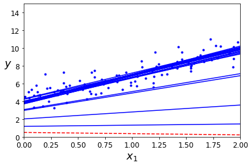

```python
n_epochs = 50
t0, t1 = 5, 50  # learning schedule hyperparameters

def learning_schedule(t):
    return t0 / (t + t1)

theta = np.random.randn(2,1)  # random initialization

for epoch in range(n_epochs):
    for i in range(m):
        if epoch == 0 and i < 20:                    # not shown in the book
            y_predict = X_new_b.dot(theta)           # not shown
            style = "b-" if i > 0 else "r--"         # not shown
            plt.plot(X_new, y_predict, style)        # not shown
        random_index = np.random.randint(m)
        xi = X_b[random_index:random_index+1]
        yi = y[random_index:random_index+1]
        gradients = 2 * xi.T.dot(xi.dot(theta) - yi)
        eta = learning_schedule(epoch * m + i)
        theta = theta - eta * gradients
        theta_path_sgd.append(theta)                 # not shown

plt.plot(X, y, "b.")                                 # not shown
plt.xlabel("$x_1$", fontsize=18)                     # not shown
plt.ylabel("$y$", rotation=0, fontsize=18)           # not shown
plt.axis([0, 2, 0, 15])                              # not shown
save_fig("sgd_plot")                                 # not shown
plt.show()
```

"By convention we iterate by rounds of m iterations; each round is called an epoch.  
While the Batch Gradient Descent code iterated 1,000 times through the whole training  
set, this code goes through the training set only 50 times and reaches a fairly good  
solution"

```python
theta
```

```
array([[4.21076011],
       [2.74856079]])
```

```python
from sklearn.linear_model import SGDRegressor

sgd_reg = SGDRegressor(max_iter=1000, tol=1e-3, penalty=None, eta0=0.1, random_state=42)
# Note y.ravel() flattens y
sgd_reg.fit(X, y.ravel())
```

```
SGDRegressor(eta0=0.1, penalty=None, random_state=42)
```

```python
sgd_reg.intercept_, sgd_reg.coef_
```

```
(array([4.24365286]), array([2.8250878]))
```

## Mini Batch Gradient Descent

"The last Gradient Descent algorithm we will look at is called Mini-batch Gradient  
Descent. It is quite simple to understand once you know Batch and Stochastic Gradient  
Descent: at each step, instead of computing the gradients based on the full training  
set (as in Batch GD) or based on just one instance (as in Stochastic GD), Minibatch  
GD computes the gradients on small random sets of instances called minibatches.  
The main advantage of Mini-batch GD over Stochastic GD is that you can  
get a performance boost from hardware optimization of matrix operations, especially  
when using GPUs."

"The algorithm’s progress in parameter space is less erratic than with SGD, especially  
with fairly large mini-batches. As a result, Mini-batch GD will end up walking  
around a bit closer to the minimum than SGD. But, on the other hand, it may be  
harder for it to escape from local minima (in the case of problems that suffer from  
local minima, unlike Linear Regression as we saw earlier)."

"Figure 4-11 shows the  
paths taken by the three Gradient Descent algorithms in parameter space during  
training. They all end up near the minimum, but Batch GD’s path actually stops at the  
minimum, while both Stochastic GD and Mini-batch GD continue to walk around.  
However, don’t forget that Batch GD takes a lot of time to take each step, and Stochastic  
GD and Mini-batch GD would also reach the minimum if you used a good learning  
schedule."

[figure not shown]

```python
theta_path_mgd = []

n_iterations = 50
minibatch_size = 20

np.random.seed(42)
theta = np.random.randn(2,1)  # random initialization

t0, t1 = 200, 1000
def learning_schedule(t):
    return t0 / (t + t1)

t = 0
for epoch in range(n_iterations):
    shuffled_indices = np.random.permutation(m)
    X_b_shuffled = X_b[shuffled_indices]
    y_shuffled = y[shuffled_indices]
    for i in range(0, m, minibatch_size):
        t += 1
        xi = X_b_shuffled[i:i+minibatch_size]
        yi = y_shuffled[i:i+minibatch_size]
        gradients = 2/minibatch_size * xi.T.dot(xi.dot(theta) - yi)
        eta = learning_schedule(t)
        theta = theta - eta * gradients
        theta_path_mgd.append(theta)
```

```python
theta
```

```
array([[4.25214635],
       [2.7896408 ]])
```

```python
theta_path_bgd = np.array(theta_path_bgd)
theta_path_sgd = np.array(theta_path_sgd)
theta_path_mgd = np.array(theta_path_mgd)
```

```
Saving figure gradient_descent_paths_plot
```

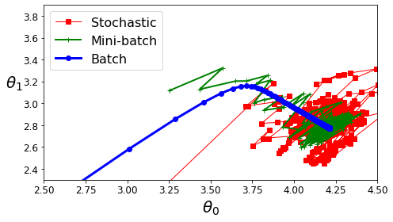

```python
plt.figure(figsize=(7,4))
plt.plot(theta_path_sgd[:, 0], theta_path_sgd[:, 1], "r-s", linewidth=1, label="Stochastic")
plt.plot(theta_path_mgd[:, 0], theta_path_mgd[:, 1], "g-+", linewidth=2, label="Mini-batch")
plt.plot(theta_path_bgd[:, 0], theta_path_bgd[:, 1], "b-o", linewidth=3, label="Batch")
plt.legend(loc="upper left", fontsize=16)
plt.xlabel(r"$\theta_0$", fontsize=20)
plt.ylabel(r"$\theta_1$   ", fontsize=20, rotation=0)
plt.axis([2.5, 4.5, 2.3, 3.9])
save_fig("gradient_descent_paths_plot")
plt.show()
```

NOTE: "There is almost no difference after training: all these algorithms  
end up with very similar models and make predictions in exactly  
the same way."

[figure not shown]

# Polynomial Regression

"What if your data is actually more complex than a simple straight line? Surprisingly,  
you can actually use a linear model to fit nonlinear data. A simple way to do this is to  
add powers of each feature as new features, then train a linear model on this extended  
set of features."

```python
import numpy as np
import numpy.random as rnd

np.random.seed(42)
```

```python
# Creating A Quadratic Graph
m = 100
X = 6 * np.random.rand(m, 1) - 3
y = 0.5 * X**2 + X + 2 + np.random.randn(m, 1)
```

```
Saving figure quadratic_data_plot
```

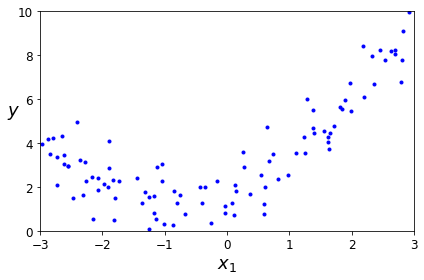

```python
plt.plot(X, y, "b.")
plt.xlabel("$x_1$", fontsize=18)
plt.ylabel("$y$", rotation=0, fontsize=18)
plt.axis([-3, 3, 0, 10])
save_fig("quadratic_data_plot")
plt.show()
```

So let’s use Scikit-Learn’s PolynomialFeatures class to transform our training data, adding the square  
(2nd-degree polynomial) of each feature in the training set as new features (in this case there is  
just one feature):

```python
from sklearn.preprocessing import PolynomialFeatures
poly_features = PolynomialFeatures(degree=2, include_bias=False)
X_poly = poly_features.fit_transform(X)
X[0]
```

```
array([-0.75275929])
```

```python
X_poly[0]
```

```
array([-0.75275929,  0.56664654])
```

```python
lin_reg = LinearRegression()
lin_reg.fit(X_poly, y)
lin_reg.intercept_, lin_reg.coef_
```

```
(array([1.78134581]), array([[0.93366893, 0.56456263]]))
```

Not a bad model! The model estimates y = 0.56x^2 + 0.93x^1 + 1.78 when in fact the original function was y = 0.5x^2 + 1.0x + 2.0 + Gaussian noise.

```
Saving figure quadratic_predictions_plot
```

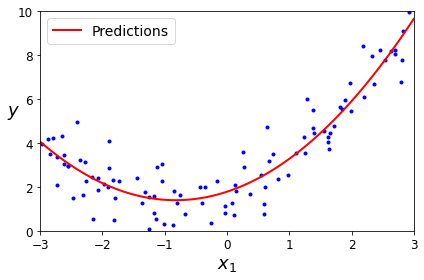

```python
X_new=np.linspace(-3, 3, 100).reshape(100, 1)
X_new_poly = poly_features.transform(X_new)
y_new = lin_reg.predict(X_new_poly)
plt.plot(X, y, "b.")
plt.plot(X_new, y_new, "r-", linewidth=2, label="Predictions")
plt.xlabel("$x_1$", fontsize=18)
plt.ylabel("$y$", rotation=0, fontsize=18)
plt.legend(loc="upper left", fontsize=14)
plt.axis([-3, 3, 0, 10])
save_fig("quadratic_predictions_plot")
plt.show()
```

"Note that when there are multiple features, Polynomial Regression is capable of finding  
relationships between features (which is something a plain Linear Regression  
model cannot do). This is made possible by the fact that PolynomialFeatures also  
adds all combinations of features up to the given degree."

"For example, if there were two features a and b, PolynomialFeatures with degree=3 would not only add the  
features a2, a3, b2, and b3, but also the combinations ab, a2b, and ab2."

[figure not shown]

# Learning Curves

"In Chapter 2 you used cross-validation to get an estimate of a model’s generalization  
performance. If a model performs well on the training data but generalizes poorly  
according to the cross-validation metrics, then your model is overfitting. If it performs  
poorly on both, then it is underfitting. This is one way to tell when a model is  
too simple or too complex."

"Another way is to look at the learning curves: these are plots of the model’s performance  
on the training set and the validation set as a function of the training set size.  
To generate the plots, simply train the model several times on different sized subsets  
of the training set. The following code defines a function that plots the learning  
curves of a model given some training data:"

```
Saving figure high_degree_polynomials_plot
```

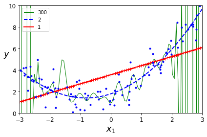

```python
from sklearn.preprocessing import StandardScaler
from sklearn.pipeline import Pipeline

for style, width, degree in (("g-", 1, 300), ("b--", 2, 2), ("r-+", 2, 1)):
    polybig_features = PolynomialFeatures(degree=degree, include_bias=False)
    std_scaler = StandardScaler()
    lin_reg = LinearRegression()
    polynomial_regression = Pipeline([
            ("poly_features", polybig_features),
            ("std_scaler", std_scaler),
            ("lin_reg", lin_reg),
        ])
    polynomial_regression.fit(X, y)
    y_newbig = polynomial_regression.predict(X_new)
    plt.plot(X_new, y_newbig, style, label=str(degree), linewidth=width)

plt.plot(X, y, "b.", linewidth=3)
plt.legend(loc="upper left")
plt.xlabel("$x_1$", fontsize=18)
plt.ylabel("$y$", rotation=0, fontsize=18)
plt.axis([-3, 3, 0, 10])
save_fig("high_degree_polynomials_plot")
plt.show()
```

```python
from sklearn.metrics import mean_squared_error
from sklearn.model_selection import train_test_split

def plot_learning_curves(model, X, y):
    X_train, X_val, y_train, y_val = train_test_split(X, y, test_size=0.2, random_state=10)
    train_errors, val_errors = [], []
    for m in range(1, len(X_train)):
        model.fit(X_train[:m], y_train[:m])
        y_train_predict = model.predict(X_train[:m])
        y_val_predict = model.predict(X_val)
        train_errors.append(mean_squared_error(y_train[:m], y_train_predict))
        val_errors.append(mean_squared_error(y_val, y_val_predict))

    plt.plot(np.sqrt(train_errors), "r-+", linewidth=2, label="train")
    plt.plot(np.sqrt(val_errors), "b-", linewidth=3, label="val")
    plt.legend(loc="upper right", fontsize=14)   # not shown in the book
    plt.xlabel("Training set size", fontsize=14) # not shown
    plt.ylabel("RMSE", fontsize=14)              # not shown
```

```
Saving figure underfitting_learning_curves_plot
```

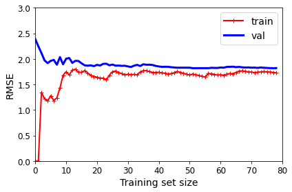

```python
lin_reg = LinearRegression()
plot_learning_curves(lin_reg, X, y)
plt.axis([0, 80, 0, 3])                         # not shown in the book
save_fig("underfitting_learning_curves_plot")   # not shown
plt.show()                                      # not shown
```

### Analysis

##### Underfitting

"When there are just one or two instances in the training set, the model can fit  
them perfectly, which is why the curve starts at zero. But as new instances are added  
to the training set, it becomes impossible for the model to fit the training data perfectly,  
both because the data is noisy and because it is not linear at all. So the error on  
the training data goes up until it reaches a plateau, at which point adding new instances  
to the training set doesn’t make the average error much better or worse."

"Now let’slook at the performance of the model on the validation data. When the model is  
trained on very few training instances, it is incapable of generalizing properly, which  
is why the validation error is initially quite big. Then as the model is shown more  
training examples, it learns and thus the validation error slowly goes down. However,  
once again a straight line cannot do a good job modeling the data, so the error ends  
up at a plateau, very close to the other curve."

TIP: "If your model is underfitting the training data, adding more training  
examples will not help. You need to use a more complex model  
or come up with better features."

```
Saving figure learning_curves_plot
```

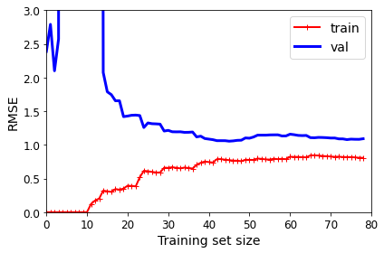

```python
from sklearn.pipeline import Pipeline

polynomial_regression = Pipeline([
        ("poly_features", PolynomialFeatures(degree=10, include_bias=False)),
        ("lin_reg", LinearRegression()),
    ])

plot_learning_curves(polynomial_regression, X, y)
plt.axis([0, 80, 0, 3])           # not shown
save_fig("learning_curves_plot")  # not shown
plt.show()
```

### Analysis

##### Overfitting

These learning curves look a bit like the previous ones, but there are two very important differences:

- The error on the training data is much lower than with the Linear Regression model.
- There is a gap between the curves. This means that the model performs significantly  
  better on the training data than on the validation data, which is the hallmark  
  of an overfitting model. However, if you used a much larger training set,  
  the two curves would continue to get closer.

TIP: "One way to improve an overfitting model is to feed it more training  
data until the validation error reaches the training error."

[figure not shown]

# Regularized Linear Models

"As we saw in Chapters 1 and 2, a good way to reduce overfitting is to regularize the  
model (i.e., to constrain it): the fewer degrees of freedom it has, the harder it will be  
for it to overfit the data. For example, a simple way to regularize a polynomial model  
is to reduce the number of polynomial degrees."

"For a linear model, regularization is typically achieved by constraining the weights of  
the model. We will now look at Ridge Regression, Lasso Regression, and Elastic Net,  
which implement three different ways to constrain the weights."

## Ridge Regression

"Note that the regularization term should only be added  
to the cost function during training. Once the model is trained, you want to evaluate  
the model’s performance using the unregularized performance measure."

[figure not shown]

WARNING: "It is important to scale the data (e.g., using a StandardScaler)  
before performing Ridge Regression, as it is sensitive to the scale of  
the input features. This is true of most regularized models."

```python
np.random.seed(42)
m = 20
X = 3 * np.random.rand(m, 1)
y = 1 + 0.5 * X + np.random.randn(m, 1) / 1.5
X_new = np.linspace(0, 3, 100).reshape(100, 1)
```

"Here is how to perform Ridge Regression with Scikit-Learn using a closed-form solution  
(a variant of Equation 4-9 using a matrix factorization technique by André-Louis  
Cholesky):"

```python
from sklearn.linear_model import Ridge
ridge_reg = Ridge(alpha=1, solver="cholesky", random_state=42)
ridge_reg.fit(X, y)
ridge_reg.predict([[1.5]])
```

```
array([[1.55071465]])
```

```python
ridge_reg = Ridge(alpha=1, solver="sag", random_state=42)
ridge_reg.fit(X, y)
ridge_reg.predict([[1.5]])
```

```
array([[1.5507201]])
```

```
Saving figure ridge_regression_plot
```

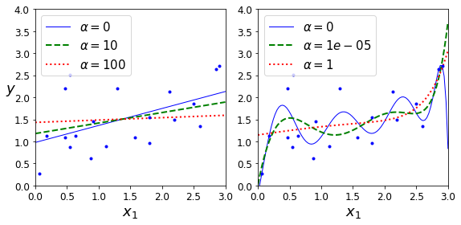

```python
from sklearn.linear_model import Ridge

# https://scikit-learn.org/stable/modules/generated/sklearn.linear_model.Ridge.html
# https://scikit-learn.org/stable/modules/generated/sklearn.linear_model.Lasso.html
# This function effectively takes in the model_class = Ridge / Lasso / Etc
# If polynomial = True or False. If true, pick degree 10
# Alphas = hyperparamater value
# **model_kargs == ramdon_state
def plot_model(model_class, polynomial, alphas, **model_kargs):
    for alpha, style in zip(alphas, ("b-", "g--", "r:")):
        model = model_class(alpha, **model_kargs) if alpha > 0 else LinearRegression()
        if polynomial:
            model = Pipeline([
                    ("poly_features", PolynomialFeatures(degree=10, include_bias=False)),
                    ("std_scaler", StandardScaler()),
                    ("regul_reg", model),
                ])
        model.fit(X, y)
        y_new_regul = model.predict(X_new)
        lw = 2 if alpha > 0 else 1
        plt.plot(X_new, y_new_regul, style, linewidth=lw, label=r"$\alpha = {}$".format(alpha))
    plt.plot(X, y, "b.", linewidth=3)
    plt.legend(loc="upper left", fontsize=15)
    plt.xlabel("$x_1$", fontsize=18)
    plt.axis([0, 3, 0, 4])

plt.figure(figsize=(8,4))
plt.subplot(121)
plot_model(Ridge, polynomial=False, alphas=(0, 10, 100), random_state=42)
plt.ylabel("$y$", rotation=0, fontsize=18)
plt.subplot(122)
plot_model(Ridge, polynomial=True, alphas=(0, 10**-5, 1), random_state=42)

save_fig("ridge_regression_plot")
plt.show()
```

"The hyperparameter α controls how much you want to regularize the model. If α = 0  
then Ridge Regression is just Linear Regression. If α is very large, then all weights end  
up very close to zero and the result is a flat line going through the data’s mean."

And using Stochastic Gradient Descent:

Note: "The penalty hyperparameter sets the type of regularization term to use. Specifying  
"l2" indicates that you want SGD to add a regularization term to the cost function  
equal to half the square of the ℓ2 norm of the weight vector: this is simply Ridge  
Regression."

```python
sgd_reg = SGDRegressor(penalty="l2", max_iter=1000, tol=1e-3, random_state=42)
sgd_reg.fit(X, y.ravel())
sgd_reg.predict([[1.5]])
```

```
array([1.47012588])
```

## Lasso Regression

"Least Absolute Shrinkage and Selection Operator Regression (simply called Lasso  
Regression) is another regularized version of Linear Regression: just like Ridge  
Regression, it adds a regularization term to the cost function, but it uses the ℓ1 norm  
of the weight vector instead of half the square of the ℓ2 norm"

[figure not shown]

```
Saving figure lasso_regression_plot
```

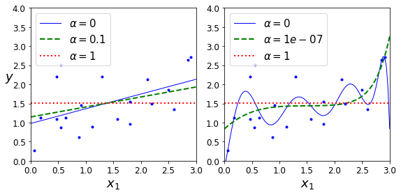

```python
from sklearn.linear_model import Lasso

plt.figure(figsize=(8,4))
plt.subplot(121)
plot_model(Lasso, polynomial=False, alphas=(0, 0.1, 1), random_state=42)
plt.ylabel("$y$", rotation=0, fontsize=18)
plt.subplot(122)
plot_model(Lasso, polynomial=True, alphas=(0, 10**-7, 1), random_state=42)

save_fig("lasso_regression_plot")
plt.show()
```

Note: "An important characteristic of Lasso Regression is that it tends to completely eliminate  
the weights of the least important features (i.e., set them to zero). For example,  
the dashed line in the right plot on Figure 4-18 (with α = 10-7) looks quadratic, almost  
linear: all the weights for the high-degree polynomial features are equal to zero. In  
other words, Lasso Regression automatically performs feature selection and outputs a  
sparse model (i.e., with few nonzero feature weights)."

TIP: "On the Lasso cost function, the BGD path tends to bounce across  
the gutter toward the end. This is because the slope changes  
abruptly at θ2 = 0. You need to gradually reduce the learning rate in  
order to actually converge to the global minimum."

Pg 130 - 131

```python
from sklearn.linear_model import Lasso
lasso_reg = Lasso(alpha=0.1)
lasso_reg.fit(X, y)
lasso_reg.predict([[1.5]])
```

```
array([1.53788174])
```

## Elastic Net

"Elastic Net is a middle ground between Ridge Regression and Lasso Regression. The  
regularization term is a simple mix of both Ridge and Lasso’s regularization terms,  
and you can control the mix ratio r. When r = 0, Elastic Net is equivalent to Ridge  
Regression, and when r = 1, it is equivalent to Lasso Regression"

[figure not shown]

TIP: "So when should you use Linear Regression, Ridge, Lasso, or Elastic Net? It is almost  
always preferable to have at least a little bit of regularization, so generally you should  
avoid plain Linear Regression. Ridge is a good default, but if you suspect that only a  
few features are actually useful, you should prefer Lasso or Elastic Net since they tend  
to reduce the useless features’ weights down to zero as we have discussed. In general,  
Elastic Net is preferred over Lasso since Lasso may behave erratically when the number  
of features is greater than the number of training instances or when several features  
are strongly correlated."

```python
from sklearn.linear_model import ElasticNet
elastic_net = ElasticNet(alpha=0.1, l1_ratio=0.5, random_state=42)
elastic_net.fit(X, y)
elastic_net.predict([[1.5]])
```

```
array([1.54333232])
```

## Early Stopping

"A very different way to regularize iterative learning algorithms such as Gradient  
Descent is to stop training as soon as the validation error reaches a minimum. This is  
called early stopping."

"Figure 4-20 shows a complex model (in this case a high-degree  
Polynomial Regression model) being trained using Batch Gradient Descent. As the  
epochs go by, the algorithm learns and its prediction error (RMSE) on the training set  
naturally goes down, and so does its prediction error on the validation set. However,  
after a while the validation error stops decreasing and actually starts to go back up.  
This indicates that the model has started to overfit the training data. With early stopping  
you just stop training as soon as the validation error reaches the minimum. It is  
such a simple and efficient regularization technique that Geoffrey Hinton called it a  
“beautiful free lunch.”

```python
np.random.seed(42)
m = 100
X = 6 * np.random.rand(m, 1) - 3
y = 2 + X + 0.5 * X**2 + np.random.randn(m, 1)

X_train, X_val, y_train, y_val = train_test_split(X[:50], y[:50].ravel(), test_size=0.5, random_state=10)
```

### Basic Implementation!

```python
from copy import deepcopy

poly_scaler = Pipeline([
        ("poly_features", PolynomialFeatures(degree=90, include_bias=False)),
        ("std_scaler", StandardScaler())
    ])

X_train_poly_scaled = poly_scaler.fit_transform(X_train)
X_val_poly_scaled = poly_scaler.transform(X_val)

sgd_reg = SGDRegressor(max_iter=1, tol=-np.infty, warm_start=True,
                       penalty=None, learning_rate="constant", eta0=0.0005, random_state=42)

minimum_val_error = float("inf")
best_epoch = None
best_model = None
for epoch in range(1000):
    sgd_reg.fit(X_train_poly_scaled, y_train)  # continues where it left off
    y_val_predict = sgd_reg.predict(X_val_poly_scaled)
    val_error = mean_squared_error(y_val, y_val_predict)
    if val_error < minimum_val_error:
        minimum_val_error = val_error
        best_epoch = epoch
        best_model = deepcopy(sgd_reg)
```

### Basic Implementation Graphed

```
Saving figure early_stopping_plot
```

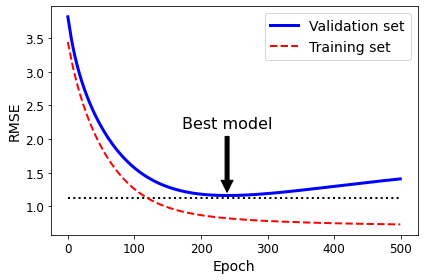

```python
sgd_reg = SGDRegressor(max_iter=1, tol=-np.infty, warm_start=True,
                       penalty=None, learning_rate="constant", eta0=0.0005, random_state=42)

n_epochs = 500
train_errors, val_errors = [], []
for epoch in range(n_epochs):
    sgd_reg.fit(X_train_poly_scaled, y_train)
    y_train_predict = sgd_reg.predict(X_train_poly_scaled)
    y_val_predict = sgd_reg.predict(X_val_poly_scaled)
    train_errors.append(mean_squared_error(y_train, y_train_predict))
    val_errors.append(mean_squared_error(y_val, y_val_predict))

best_epoch = np.argmin(val_errors)
best_val_rmse = np.sqrt(val_errors[best_epoch])

plt.annotate('Best model',
             xy=(best_epoch, best_val_rmse),
             xytext=(best_epoch, best_val_rmse + 1),
             ha="center",
             arrowprops=dict(facecolor='black', shrink=0.05),
             fontsize=16,
            )

best_val_rmse -= 0.03  # just to make the graph look better
plt.plot([0, n_epochs], [best_val_rmse, best_val_rmse], "k:", linewidth=2)
plt.plot(np.sqrt(val_errors), "b-", linewidth=3, label="Validation set")
plt.plot(np.sqrt(train_errors), "r--", linewidth=2, label="Training set")
plt.legend(loc="upper right", fontsize=14)
plt.xlabel("Epoch", fontsize=14)
plt.ylabel("RMSE", fontsize=14)
save_fig("early_stopping_plot")
plt.show()
```

NOTE: "With Stochastic and Mini-batch Gradient Descent, the curves are  
not so smooth, and it may be hard to know whether you have  
reached the minimum or not. One solution is to stop only after the  
validation error has been above the minimum for some time (when  
you are confident that the model will not do any better), then roll  
back the model parameters to the point where the validation error  
was at a minimum."

# Logistic Regression

"As we discussed in Chapter 1, some regression algorithms can be used for classification  
as well (and vice versa). Logistic Regression (also called Logit Regression) is commonly  
used to estimate the probability that an instance belongs to a particular class  
(e.g., what is the probability that this email is spam?). If the estimated probability is  
greater than 50%, then the model predicts that the instance belongs to that class  
(called the positive class, labeled “1”), or else it predicts that it does not (i.e., it  
belongs to the negative class, labeled “0”). This makes it a binary classifier."

## Estimating Probabilities

[figure not shown]

## Training and Cost Function

[figure not shown]

## Decision Boundaries

"Let’s use the iris dataset to illustrate Logistic Regression. This is a famous dataset that  
contains the sepal and petal length and width of 150 iris flowers of three different  
species: Iris-Setosa, Iris-Versicolor, and Iris-Virginica"

"Let’s try to build a classifier to detect the Iris-Virginica type based only on the petal  
width feature. First let’s load the data:"

```python
from sklearn import datasets
iris = datasets.load_iris()
list(iris.keys())
```

```
['data',
 'target',
 'frame',
 'target_names',
 'DESCR',
 'feature_names',
 'filename']
```

```python
print(iris.DESCR)
```

[output not shown]

[output cut: 8 more lines]

[output not shown]

```python
X = iris["data"][:, 3:]  # petal width
y = (iris["target"] == 2).astype(int)  # 1 if Iris virginica, else 0
```

Now let's train the Logistic Regression Model!

```python
from sklearn.linear_model import LogisticRegression
log_reg = LogisticRegression(solver="lbfgs", random_state=42)
log_reg.fit(X, y)
```

```
LogisticRegression(random_state=42)
```

Let’s look at the model’s estimated probabilities for flowers with petal widths varying  
from 0 to 3 cm

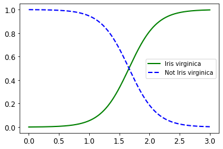

```python
X_new = np.linspace(0, 3, 1000).reshape(-1, 1)
y_proba = log_reg.predict_proba(X_new)

plt.plot(X_new, y_proba[:, 1], "g-", linewidth=2, label="Iris virginica")
plt.plot(X_new, y_proba[:, 0], "b--", linewidth=2, label="Not Iris virginica")
plt.legend()
```

"The petal width of Iris-Virginica flowers (represented by triangles) ranges from 1.4  
cm to 2.5 cm, while the other iris flowers (represented by squares) generally have a  
smaller petal width, ranging from 0.1 cm to 1.8 cm."

"Notice that there is a bit of overlap.  
Above about 2 cm the classifier is highly confident that the flower is an Iris-  
Virginica (it outputs a high probability to that class), while below 1 cm it is highly  
confident that it is not an Iris-Virginica (high probability for the “Not Iris-Virginica”  
class). In between these extremes, the classifier is unsure. However, if you ask it to  
predict the class (using the predict() method rather than the predict_proba()  
method), it will return whichever class is the most likely. Therefore, there is a decision  
boundary at around 1.6 cm where both probabilities are equal to 50%: if the petal  
width is higher than 1.6 cm, the classifier will predict that the flower is an Iris-  
Virginica, or else it will predict that it is not (even if it is not very confident):"

```
Saving figure logistic_regression_plot
```

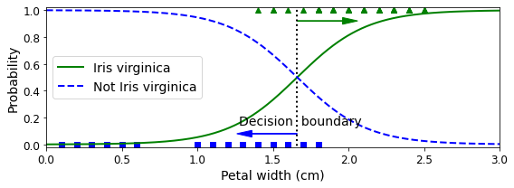

```python
X_new = np.linspace(0, 3, 1000).reshape(-1, 1)
y_proba = log_reg.predict_proba(X_new)
decision_boundary = X_new[y_proba[:, 1] >= 0.5][0]

plt.figure(figsize=(8, 3))
plt.plot(X[y==0], y[y==0], "bs")
plt.plot(X[y==1], y[y==1], "g^")
plt.plot([decision_boundary, decision_boundary], [-1, 2], "k:", linewidth=2)
plt.plot(X_new, y_proba[:, 1], "g-", linewidth=2, label="Iris virginica")
plt.plot(X_new, y_proba[:, 0], "b--", linewidth=2, label="Not Iris virginica")
plt.text(decision_boundary+0.02, 0.15, "Decision  boundary", fontsize=14, color="k", ha="center")
plt.arrow(decision_boundary, 0.08, -0.3, 0, head_width=0.05, head_length=0.1, fc='b', ec='b')
plt.arrow(decision_boundary, 0.92, 0.3, 0, head_width=0.05, head_length=0.1, fc='g', ec='g')
plt.xlabel("Petal width (cm)", fontsize=14)
plt.ylabel("Probability", fontsize=14)
plt.legend(loc="center left", fontsize=14)
plt.axis([0, 3, -0.02, 1.02])
save_fig("logistic_regression_plot")
plt.show()
```

```python
decision_boundary
```

```
array([1.66066066])
```

```python
log_reg.predict([[1.7], [1.5]])
```

```
array([1, 0])
```

```python
from sklearn.linear_model import LogisticRegression

X = iris["data"][:, (2, 3)]  # petal length, petal width
y = (iris["target"] == 2).astype(int)

log_reg = LogisticRegression(solver="lbfgs", C=10**10, random_state=42)
log_reg.fit(X, y)

x0, x1 = np.meshgrid(
        np.linspace(2.9, 7, 500).reshape(-1, 1),
        np.linspace(0.8, 2.7, 200).reshape(-1, 1),
    )
X_new = np.c_[x0.ravel(), x1.ravel()]

y_proba = log_reg.predict_proba(X_new)
```

[figure not shown]

# Softmax Regression

"The Logistic Regression model can be generalized to support multiple classes directly,  
without having to train and combine multiple binary classifiers (as discussed in  
Chapter 3). This is called Softmax Regression, or Multinomial Logistic Regression."

[figure not shown]

"Note that each class has its own dedicated parameter vector θ(k). All these vectors are  
typically stored as rows in a parameter matrix Θ"

"Once you have computed the score of every class for the instance x, you can estimate  
the probability pk that the instance belongs to class k by running the scores through  
the softmax function (Equation 4-20): it computes the exponential of every score, then normalizes them (dividing by the sum of all the exponentials).  
The scores are generally called logits or log-odds (although they are actually unnormalized logodds)."

[figure not shown]

How softmax predicts:

[figure not shown]

NOTE: "The Softmax Regression classifier predicts only one class at a time  
(i.e., it is multiclass, not multioutput) so it should be used only with  
mutually exclusive classes such as different types of plants. You  
cannot use it to recognize multiple people in one picture."

## Cross Entropy

[figure not shown]

"Let’s use Softmax Regression to classify the iris flowers into all three classes. Scikit-  
Learn’s LogisticRegression uses one-versus-all by default when you train it on more  
than two classes, but you can set the multi_class hyperparameter to "multinomial"  
to switch it to Softmax Regression instead"

```python
X = iris["data"][:, (2, 3)]  # petal length, petal width
y = iris["target"]

softmax_reg = LogisticRegression(multi_class="multinomial",solver="lbfgs", C=10, random_state=42)
softmax_reg.fit(X, y)
```

```
LogisticRegression(C=10, multi_class='multinomial', random_state=42)
```

[figure not shown]

```python
softmax_reg.predict([[5, 2]])
```

```
array([2])
```

```python
softmax_reg.predict_proba([[5, 2]])
```

```
array([[6.38014896e-07, 5.74929995e-02, 9.42506362e-01]])
```